# Sales Analysis Report - Online Store Data 📊

Author: Ana Bojescu

This notebook presents a comprehensive analysis of the dataset online_store_data.csv. My main objective is to transform raw data into actionable insights that help identify:

🔝 Best-selling products,

🗂️ The most and least successful product categories,

📈 Key factors that drive product performance (such as price, rating, stock availability).

To perform this analysis, I will use:

-pandas for data cleaning and processing,

-matplotlib and seaborn for building insightful visualizations,

-plotly.express for creating interactive and visually appealing plots with minimal code,

-and well-structured Markdown commentary to guide interpretation and support business decision-making.

## Step 1: Importing libraries

```python
import pandas as pd
import matplotlib.pyplot as plt
import seaborn as sns
import numpy as np
import plotly.express as px
```

## Load dataset

```python
df = pd.read_csv("PDV5_03-Task_3-online_store_data.csv")
```

## Preview of the Dataset

To get a quick sense of what the data looks like, I display the first few rows using `df.head()`.

```python
df.head()
```

|  | product_name | category | price | quantity_in_stock | quantity_sold | brand | rating | num_of_ratings | date_added | color | revenue |
| --- | --- | --- | --- | --- | --- | --- | --- | --- | --- | --- | --- |
| 0 | iPad mini (2021) (64GB, Blue) | Tablets | 499.00 | 266.0 | 807.0 | Apple | 8.75 | 151.0 | 2/2/2022 | blue | 402693.00 |
| 1 | K55 RGB (Red) | Keyboards | 49.99 | 0.0 | 1117.0 | Corsair | 8.50 | 455.0 | 8/14/2022 | red | 55838.83 |
| 2 | Fenix 7 (Purple) | Watches | 699.99 | 0.0 | 530.0 | Garmin | 9.20 | 305.0 | 4/20/2022 | purple | 370994.70 |
| 3 | Mate 40 (256GB, Orange) | Smartphones | 899.00 | 182.0 | 1030.0 | Huawei | 8.50 | 500.0 | 10/23/2024 | orange | 925970.00 |
| 4 | Rival 600 (Red) | Mice | 79.99 | 35.0 | 1439.0 | SteelSeries | 9.25 | 556.0 | 9/29/2020 | red | 115105.61 |

## Step 3: Distribution of Quantity Sold 📦

I examine how units sold are distributed across all products. This helps me identify outliers and top-performing items

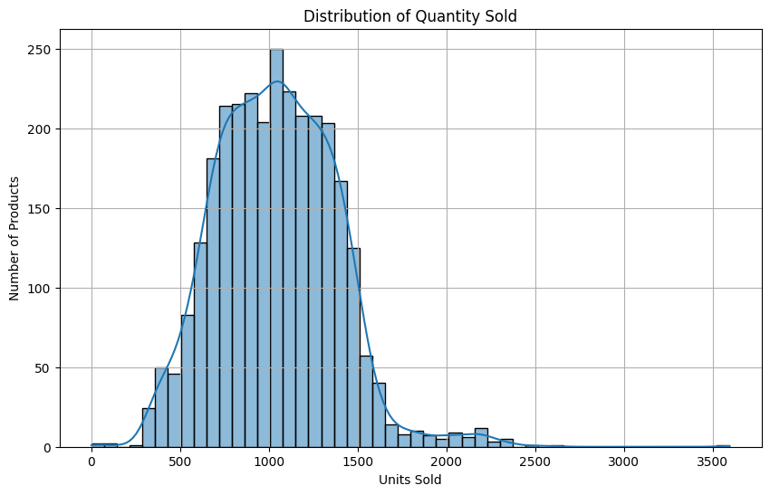

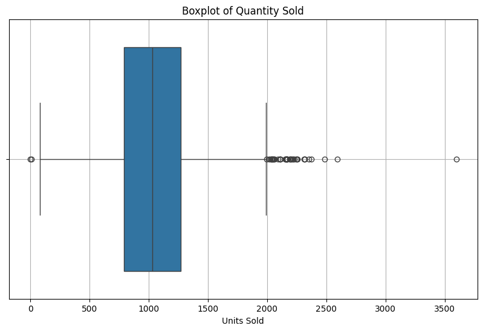

```python
plt.figure(figsize=(10, 6))
sns.histplot(df['quantity_sold'], bins=50, kde=True)
plt.title('Distribution of Quantity Sold')
plt.xlabel('Units Sold')
plt.ylabel('Number of Products')
plt.grid(True)
plt.show()

plt.figure(figsize=(10, 6))
sns.boxplot(x=df['quantity_sold'])
plt.title('Boxplot of Quantity Sold')
plt.xlabel('Units Sold')
plt.grid(True)
plt.show()
```

## Step 4: Sales Performance by Category 🗂️

I compare units sold across categories using boxplots to reveal which categories are performing the best.

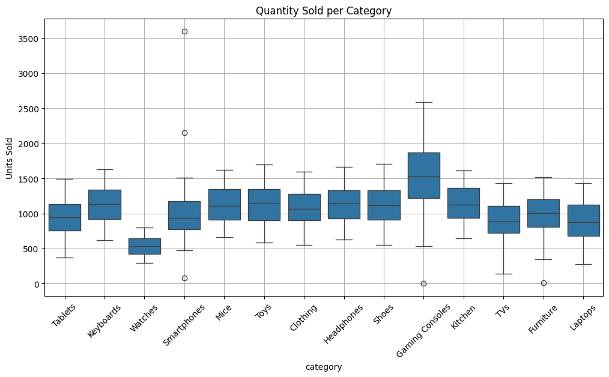

```python
plt.figure(figsize=(12, 6))
sns.boxplot(data=df, x='category', y='quantity_sold')
plt.title('Quantity Sold per Category')
plt.xticks(rotation=45)
plt.ylabel('Units Sold')
plt.grid(True)
plt.show()
```

## Step 5: Correlation Analysis 📈

I calculate and visualize the correlations between numeric variables like price, rating, stock, and revenue to better understand which factors are driving sales.

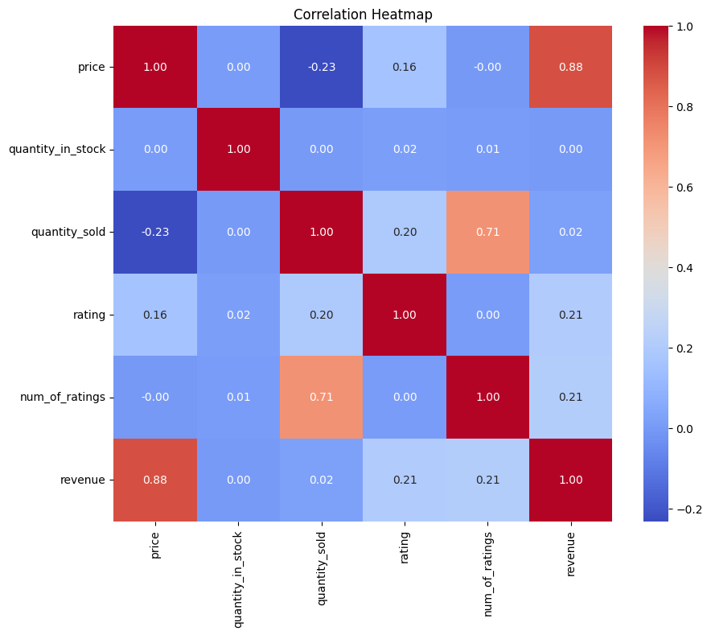

```python
correlation_matrix = df.corr(numeric_only=True)
plt.figure(figsize=(10, 8))
sns.heatmap(correlation_matrix, annot=True, cmap='coolwarm', fmt=".2f")
plt.title('Correlation Heatmap')
plt.show()
```

## Step 6: Key Success Factors - Scatter Analysis 🎯

I’ll visualize how specific features (such as price and rating) relate to quantity sold, and I’ll optionally enhance the plots by adding color or size mappings to enrich the visual insight.

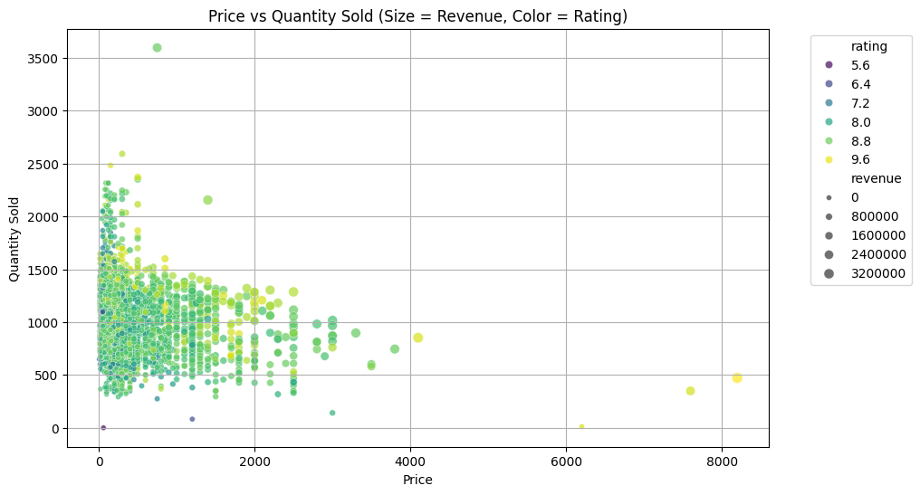

```python
plt.figure(figsize=(10, 6))
sns.scatterplot(data=df, x='price', y='quantity_sold', size='revenue', hue='rating', palette='viridis', alpha=0.7)
plt.title('Price vs Quantity Sold (Size = Revenue, Color = Rating)')
plt.xlabel('Price')
plt.ylabel('Quantity Sold')
plt.legend(bbox_to_anchor=(1.05, 1), loc='upper left')
plt.grid(True)
plt.show()
```

## Interactive: Price vs Quantity Sold

```python
fig = px.scatter(
    df,
    x='price',
    y='quantity_sold',
    size='revenue',
    color='category',
    hover_data=['product_name', 'rating'],
    title='Interactive: Price vs Quantity Sold'
)
fig.show()
```

[output not shown]

## Final Conclusions 🧠

After conducting this analysis, here’s what I’ve discovered:

🔝 A few products clearly stand out as top sellers — this became evident through both histograms and boxplots.

## 🎯 Business Implications

-I recommend focusing marketing efforts on categories that consistently perform well and have high user satisfaction.

-Introducing dynamic pricing for high-rated but lower-volume products could help increase their sales potential.

-It’s important to actively monitor stock levels for popular items — running out of stock could mean missed revenue opportunities.

*By going beyond the basic analysis — through annotations, interactive visuals, and extra insights — I can make the report not just informative, but also engaging and actionable. These enhancements help the team spot key patterns faster and make better decisions with confidence.